# Assignment 4

STATS 220 Semester One 2022

```css
body {
background-color: #FDD2DD
}
@import url('https://fonts.googleapis.com/css2?family=Rubik+Moonrocks&display=swap');

h1,
h2,
h3,
h4,
h5

{
font-family: 'Rubik Moonrocks', cursive;
}
```

## Mean danceability against mode name

```r
song_data<- fromJSON("json data.json")

mean_data <- song_data %>%
  group_by(mode_name)%>%
  summarise(mean_danceability = mean(danceability, na.rm= TRUE))%>%
  arrange(mean_danceability)
mean_data
```

```
## # A tibble: 2 x 2
##   mode_name mean_danceability
##   <chr>                 <dbl>
## 1 major                 0.476
## 2 minor                 0.479
```

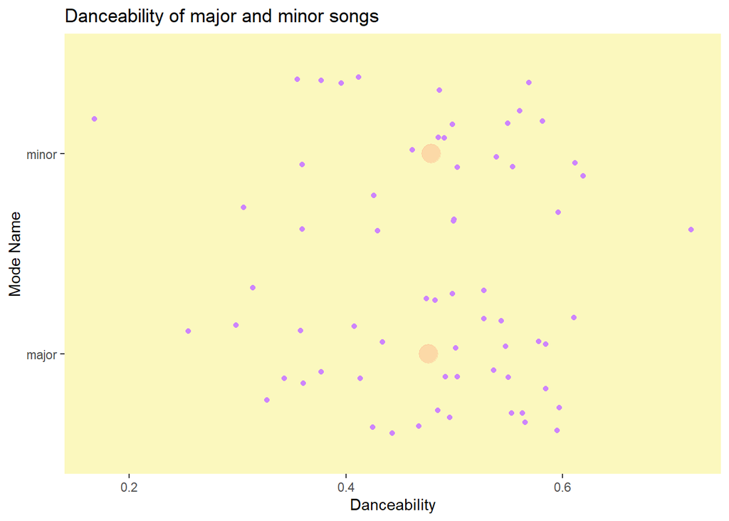

```r
ggplot()+
  geom_jitter(data= song_data,
              aes(x =danceability, y= mode_name),
              height=0.4,
              color= "#CD84FD") +
  geom_point(data=mean_data,
             aes(x=mean_danceability, y=mode_name),
color="#FDAB84",
alpha= 0.4,
size=6,
shape=19) +
  labs( title= "Danceability of major and minor songs",
        x="Danceability",
        y="Mode Name")+
  theme(panel.background = element_rect(fill ="#FBF8BE"))+
  theme(panel.grid.major = element_blank(), panel.grid.minor = element_blank())
```

## Mean danceability against duration in minutes

[figure not shown]

```r
song_data<- fromJSON("json data.json")%>%
  mutate(duration_min= duration_ms/1000/60)


danceability_mean <- song_data$danceability %>% mean(na.rm = TRUE) %>% round(1)


ggplot()+
  geom_jitter(data=song_data,
              aes(x=danceability,
                  y= duration_min),
                  color="#3945F5",
                  alpha=0.7) +
  geom_vline(xintercept = danceability_mean,
             alpha= 0.5,
             color ="#C1BEFB")+
  labs( title= "Danceability compared to the duration in minutes",
        x="Danceability",
        y="Duration in Minutes")+
  theme(panel.background = element_rect(fill ="#BEF5FB"))+
  theme(panel.grid.major = element_blank(), panel.grid.minor = element_blank())+
  transition_states(danceability)+
  shadow_mark()
```

## Mean danceability against year released, subsetted by mode name

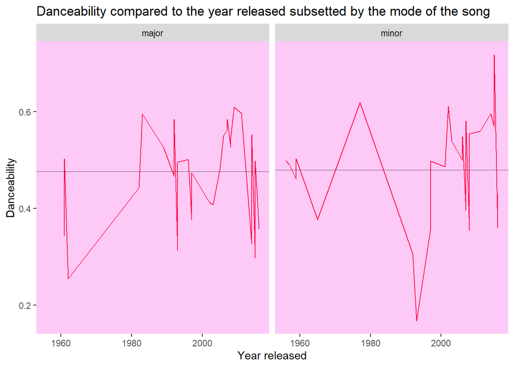

```r
song_data<- fromJSON("json data.json")

release_data <- song_data %>%
  mutate(year_released = release_date %>% str_sub(1, 4) %>% parse_number()) %>%
  count(year_released, danceability, mode_name)



release_data%>%
ggplot()+
  geom_line(aes(x=year_released,
                y=danceability),
                color= "#FF0B4D")+
  facet_wrap(vars(mode_name))+
  labs( title= "Danceability compared to the year released subsetted by the mode of the song",
        x="Year released",
        y="Danceability")+
  theme(panel.background = element_rect(fill ="#FDC9F6"))+
  theme(panel.grid.major = element_blank(), panel.grid.minor = element_blank())+

  geom_hline(data=mean_data,
             aes(yintercept =mean_danceability),
                  alpha=0.3)
```

## About my story and visulisations

I chose to make the variable danceability the main focus for my visualisations as jazz is typically a genre people enjoy dancing to and was interested in what other factors have an impact on this rating. I chose year released, duration and mode name to see if there were any particular correlations or connections that I could draw from between that variable and the danceability of the song.

I chose to use geom jitters for my first two visualisations as for my first plot compared danceability with mode name, I am able to easily sub set the two groups while having a very clear idea of the spread of the data through the points and the use of geom point to give a clear indication of the mean for both groups. I used geom jitter in my second visualisation comparing danceability and duration as I was easily able to animate the plot, emphasising the trend of the data and a vertical line to communicate the mean. I used geom line in my final visualisation as the graph type was similar to a time series graph with the line being the most appropriate to communicate this information with a horizontal line to get an overall mean for both subsets.

I applied the grammar of graphics by changing the theme of my visualisations by changing the background colours and removing the grids to make a cohesive aesthetic. I also included a facet in my third visualisation to subset on a third variable and be able to communicate extra information. I also changed the transparency on my mean indicators to still have the emphasis on the data. I added labels to my axis to make what the variables were easy to understand.

Something I tried but didn’t work was trying to group the different levels of danceability into 0.4>, 0.6>, 0.6< to do an animation by group. However, I was not able to find a method of this that produced the desired results so went with a gradual reveal animation.

My overall conclusion would be that visualisation and the grammar of graphics plays a big part about how data is understood and communicated to a general audience and data that is aesthetically pleasing gathers more interest to learn what the data is about.